# Grafo de genes ortologos: Datos de prueba de Proteinortho

Se utilizo el software *Proteinortho* para obtener las relaciones de ortología entre pares de genes de un set de prueba que simulan pertenecer a distintas especies(C, E, M y L). Se obtuvo un archivo (*.proteinortho-graph) cuyas columnas contienen los pares de genes entre los que se encontro una relación de ortología; El evalue y bitscore en ambas direcciones.

De ese archivo se extrajeron las dos primeras columnas que corresponderia a los pares de genes donde se hallo ortología(En archivo *Prueba_aristas.csv*)

```r
library(igraph)         # Biblioteca para análisis de redes.
library(tidyverse)      # Colección de bibliotecas para manipulación de datos.
library(viridis)        # Biblioteca con paletas de colores.
library(readr)
Aristas <- read.csv("Prueba_aristas.csv") #Carga el documento
Aristas #Muestra el objeto "Aristas"
```

| Especie.A | Especie.B |
| --- | --- |
| E_10 | C_10 |
| E_11 | C_11 |
| E_13 | C_13 |
| E_14 | C_14 |
| E_15 | C_15 |
| E_16 | C_16 |
| E_17 | C_17 |
| E_18 | C_64 |
| E_19 | C_22 |
| E_19 | C_63 |

[output cut: 108 more lines]

Procedemos a usar la libreria *igraph* para convertir nuestra lista de aristas en una red *G*

```r
Aristas %>%
  graph_from_data_frame -> G
G<-as.undirected(G)
  G #Damos un vistazo a la red
```

```
## IGRAPH 9c7fd59 UN-- 112 118 --
## + attr: name (v/c)
## + edges from 9c7fd59 (vertex names):
##  [1] E_10 --M_10  E_11 --M_11  E_14 --M_14  E_15 --M_15  E_16 --M_16
##  [6] E_17 --M_17  E_18 --M_18  E_19 --M_19  E_313--M_313 E_13 --M_621
## [11] E_10 --L_10  M_10 --L_10  E_11 --L_11  M_11 --L_11  E_14 --L_14
## [16] M_14 --L_14  E_15 --L_15  M_15 --L_15  E_16 --L_16  M_16 --L_16
## [21] E_17 --L_17  M_17 --L_17  E_18 --L_18  M_18 --L_18  E_19 --L_19
## [26] M_19 --L_19  M_2  --L_2   M_20 --L_20  E_313--L_313 M_313--L_313
## [31] E_368--L_323 E_13 --L_621 M_621--L_621 E_368--L_627 E_368--M_627
## [36] L_627--M_627 M_317--L_317 M_617--L_617 E_10 --C_10  M_10 --C_10
## + ... omitted several edges
```

Podemos ahora comenzar a calcular algunas metricas y visualizar la red

```r
V(G) # Nodos de la red.
```

```
## + 112/112 vertices, named, from 9c7fd59:
##   [1] E_10  E_11  E_13  E_14  E_15  E_16  E_17  E_18  E_19  E_313 E_315 E_368
##  [13] M_10  M_11  M_14  M_15  M_16  M_17  M_18  M_19  M_2   M_20  M_313 M_621
##  [25] M_630 L_10  L_11  L_14  L_15  L_16  L_17  L_18  L_19  L_2   L_20  L_313
##  [37] L_323 L_621 L_627 M_3   M_317 M_319 M_328 M_331 M_333 M_336 M_4   M_5
##  [49] M_6   M_617 M_619 M_623 M_627 M_632 M_636 M_638 M_640 M_642 M_644 M_646
##  [61] M_649 M_8   M_9   L_317 L_617 M_323 M_634 C_10  C_11  C_13  C_14  C_15
##  [73] C_16  C_17  C_64  C_22  C_63  C_12  C_1   C_164 C_166 C_167 C_2   C_20
##  [85] C_21  L_3   L_319 L_328 L_331 L_333 L_336 L_4   L_5   L_6   L_619 L_623
##  [97] L_631 L_633 L_635 L_637 L_639 L_641 L_643 L_645 L_647 L_8   L_9   E_437
## [109] E_432 E_367 E_317 E_366
```

```r
get.data.frame(G, what="vertices")
```

|  | name |
| --- | --- |
| E_10 | E_10 |
| E_11 | E_11 |
| E_13 | E_13 |
| E_14 | E_14 |
| E_15 | E_15 |
| E_16 | E_16 |
| E_17 | E_17 |
| E_18 | E_18 |
| E_19 | E_19 |
| E_313 | E_313 |

[output cut: 102 more lines]

```r
E(G) # Aristas de la red.
```

```
## + 118/118 edges from 9c7fd59 (vertex names):
##  [1] E_10 --M_10  E_11 --M_11  E_14 --M_14  E_15 --M_15  E_16 --M_16
##  [6] E_17 --M_17  E_18 --M_18  E_19 --M_19  E_313--M_313 E_13 --M_621
## [11] E_10 --L_10  M_10 --L_10  E_11 --L_11  M_11 --L_11  E_14 --L_14
## [16] M_14 --L_14  E_15 --L_15  M_15 --L_15  E_16 --L_16  M_16 --L_16
## [21] E_17 --L_17  M_17 --L_17  E_18 --L_18  M_18 --L_18  E_19 --L_19
## [26] M_19 --L_19  M_2  --L_2   M_20 --L_20  E_313--L_313 M_313--L_313
## [31] E_368--L_323 E_13 --L_621 M_621--L_621 E_368--L_627 E_368--M_627
## [36] L_627--M_627 M_317--L_317 M_617--L_617 E_10 --C_10  M_10 --C_10
## [41] L_10 --C_10  E_11 --C_11  M_11 --C_11  L_11 --C_11  E_13 --C_13
## [46] M_621--C_13  L_621--C_13  E_14 --C_14  M_14 --C_14  L_14 --C_14
## + ... omitted several edges
```

```r
get.data.frame(G, what="edges")
```

|  | from | to |
| --- | --- | --- |
| 1 | E_10 | M_10 |
| 2 | E_11 | M_11 |
| 3 | E_14 | M_14 |
| 4 | E_15 | M_15 |
| 5 | E_16 | M_16 |
| 6 | E_17 | M_17 |
| 7 | E_18 | M_18 |
| 8 | E_19 | M_19 |
| 9 | E_313 | M_313 |
| 10 | E_13 | M_621 |

[output cut: 108 more lines]

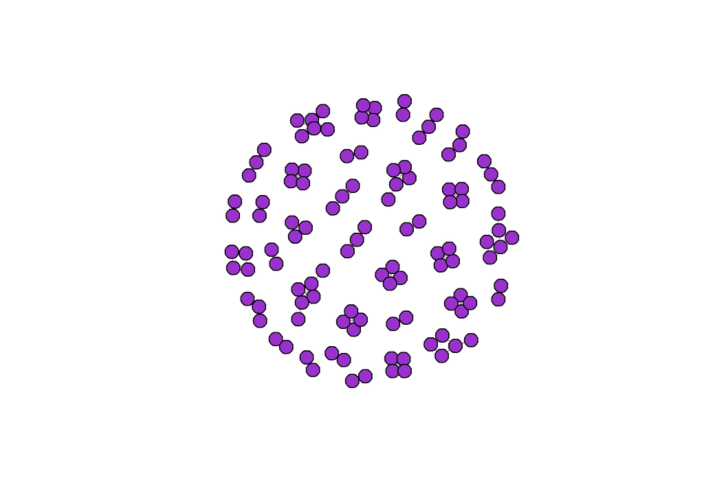

```r
#Vizualización
set.seed(22051996)
plot(G,
     vertex.size=10,
     vertex.color="darkorchid",
     vertex.label=NA)    # No queremos ver las etiquetas de los nodos.
```

```r
V(G)$degree <- degree(G)
get.data.frame(G,what="vertices")
```

|  | name | degree |
| --- | --- | --- |
| E_10 | E_10 | 3 |
| E_11 | E_11 | 3 |
| E_13 | E_13 | 3 |
| E_14 | E_14 | 3 |
| E_15 | E_15 | 3 |
| E_16 | E_16 | 3 |
| E_17 | E_17 | 3 |
| E_18 | E_18 | 3 |
| E_19 | E_19 | 4 |
| E_313 | E_313 | 3 |

[output cut: 102 more lines]

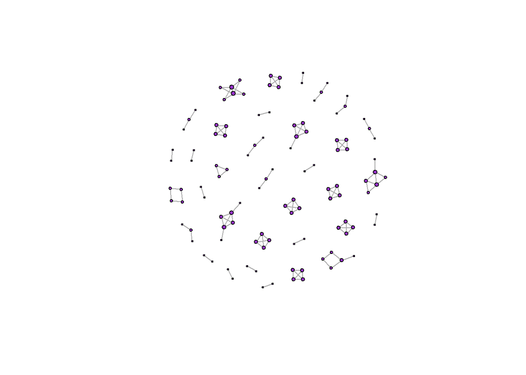

```r
# Ajustamos el tamaño de los nodos.
set.seed(22051996)
plot(G,
     vertex.size=2*sqrt(V(G)$degree),
     vertex.color="darkorchid",
     vertex.label=NA)
```

```r
# Vemos cuáles son los nodos de mayor grado.

degree(G) %>% sort(decreasing=TRUE)
```

```
##   M_2   L_2  E_19 E_368 L_313  C_12   C_1  E_10  E_11  E_13  E_14  E_15  E_16
##     5     5     4     4     4     4     4     3     3     3     3     3     3
##  E_17  E_18 E_313  M_10  M_11  M_14  M_15  M_16  M_17  M_18  M_19 M_313 M_621
##     3     3     3     3     3     3     3     3     3     3     3     3     3
##  L_10  L_11  L_14  L_15  L_16  L_17  L_18  L_19 L_621 L_627  C_10  C_11  C_13
##     3     3     3     3     3     3     3     3     3     3     3     3     3
##  C_14  C_15  C_16  C_17  C_64  C_63 L_641  M_20  L_20 L_323 M_319 M_336 M_627
##     3     3     3     3     3     3     3     2     2     2     2     2     2
## M_632 M_638 M_640 M_642 M_644 M_646 L_317 L_617 C_164 C_166 C_167   C_2  C_20
##     2     2     2     2     2     2     2     2     2     2     2     2     2
## L_643 L_645 L_647 E_317 E_315 M_630   M_3 M_317 M_328 M_331 M_333   M_4   M_5
##     2     2     2     2     1     1     1     1     1     1     1     1     1
##   M_6 M_617 M_619 M_623 M_636 M_649   M_8   M_9 M_323 M_634  C_22  C_21   L_3
##     1     1     1     1     1     1     1     1     1     1     1     1     1
## L_319 L_328 L_331 L_333 L_336   L_4   L_5   L_6 L_619 L_623 L_631 L_633 L_635
##     1     1     1     1     1     1     1     1     1     1     1     1     1
## L_637 L_639   L_8   L_9 E_437 E_432 E_367 E_366
##     1     1     1     1     1     1     1     1
```

```r
get.data.frame(G,what="vertices") %>%
  as_tibble() %>%
  arrange(-degree) %>%
  head(n=30) %>%
  pull(name)
```

```
##  [1] "M_2"   "L_2"   "E_19"  "E_368" "L_313" "C_12"  "C_1"   "E_10"  "E_11"
## [10] "E_13"  "E_14"  "E_15"  "E_16"  "E_17"  "E_18"  "E_313" "M_10"  "M_11"
## [19] "M_14"  "M_15"  "M_16"  "M_17"  "M_18"  "M_19"  "M_313" "M_621" "L_10"
## [28] "L_11"  "L_14"  "L_15"
```

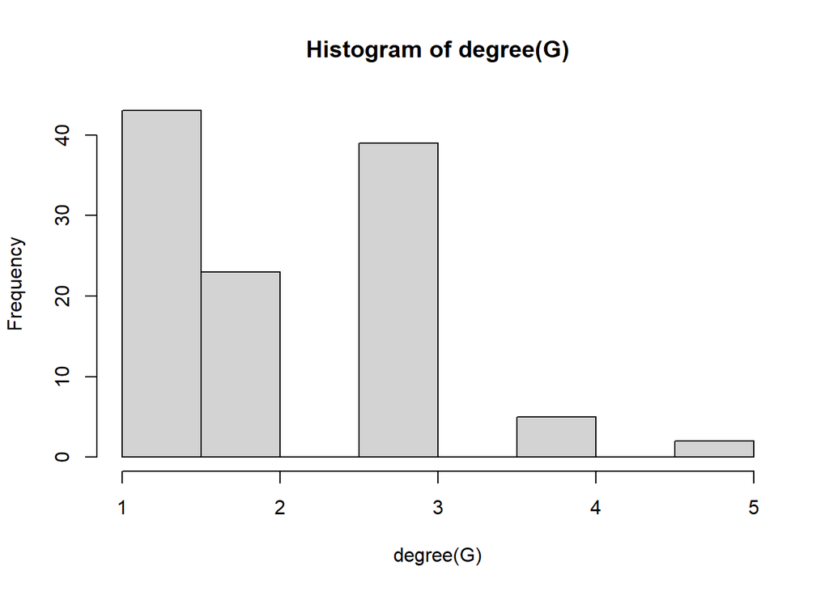

```r
#Histograma
hist(degree(G))
```

```r
is_connected(G) #¿Es G, un grafo conexo?
```

```
## [1] FALSE
```

```r
components(G) #¿A qué componente pertenece cada nodo en G?; ¿Cuál es el tamaño de los componentes;¿Cua´l es el número de componentes?
```

```
## $membership
##  E_10  E_11  E_13  E_14  E_15  E_16  E_17  E_18  E_19 E_313 E_315 E_368  M_10
##     1     2     3     4     5     6     7     8     9    10    10    11     1
##  M_11  M_14  M_15  M_16  M_17  M_18  M_19   M_2  M_20 M_313 M_621 M_630  L_10
##     2     4     5     6     7     8     9    12    13    10     3    11     1
##  L_11  L_14  L_15  L_16  L_17  L_18  L_19   L_2  L_20 L_313 L_323 L_621 L_627
##     2     4     5     6     7     8     9    12    13    10    11     3    11
##   M_3 M_317 M_319 M_328 M_331 M_333 M_336   M_4   M_5   M_6 M_617 M_619 M_623
##    14    15    16    17    18    19    20    21    22    23    24    25    26
## M_627 M_632 M_636 M_638 M_640 M_642 M_644 M_646 M_649   M_8   M_9 L_317 L_617
##    11    27    28    29    30    30    31    31    30    32    33    15    24
## M_323 M_634  C_10  C_11  C_13  C_14  C_15  C_16  C_17  C_64  C_22  C_63  C_12
##    34    34     1     2     3     4     5     6     7     8     9     9    10
##   C_1 C_164 C_166 C_167   C_2  C_20  C_21   L_3 L_319 L_328 L_331 L_333 L_336
##    11    12    12    12    12    13    10    14    16    17    18    19    20
##   L_4   L_5   L_6 L_619 L_623 L_631 L_633 L_635 L_637 L_639 L_641 L_643 L_645
##    21    22    23    25    26    27    27    28    29    29    30    30    31
## L_647   L_8   L_9 E_437 E_432 E_367 E_317 E_366
##    31    32    33    15    24    16    34    20
##
## $csize
##  [1] 4 4 4 4 4 4 4 4 5 6 6 6 3 2 3 3 2 2 2 3 2 2 2 3 2 2 3 2 3 5 4 2 2 3
##
## $no
## [1] 34
```

```r
component_distribution(G) #Distribución de componentes en G
```

```
## [1] 0.00000000 0.00000000 0.35294118 0.23529412 0.26470588 0.05882353 0.08823529
```

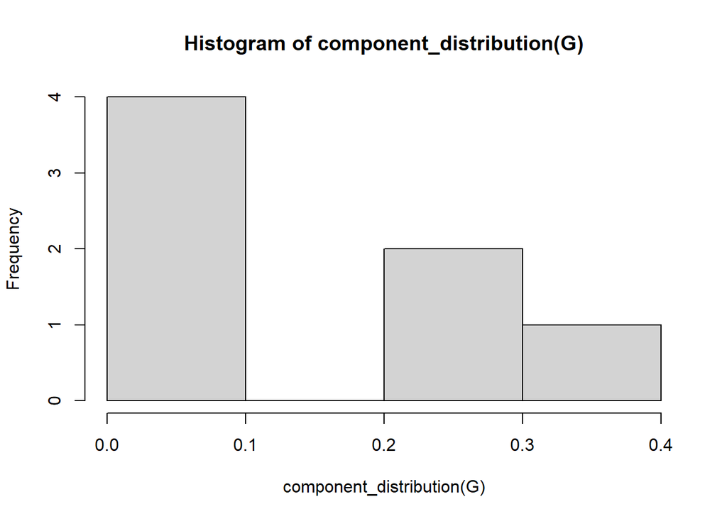

```r
hist(component_distribution(G))
```

```r
gg =decompose(G, max.comps = NA, min.vertices = 0) #Crea un grafo separado para cada componente en G
gg
```

```
## [[1]]
## IGRAPH 9ce43c5 UN-- 4 6 --
## + attr: name (v/c), degree (v/n)
## + edges from 9ce43c5 (vertex names):
## [1] E_10--M_10 E_10--L_10 M_10--L_10 E_10--C_10 M_10--C_10 L_10--C_10
##
## [[2]]
## IGRAPH 9ce43d5 UN-- 4 6 --
## + attr: name (v/c), degree (v/n)
## + edges from 9ce43d5 (vertex names):
## [1] E_11--M_11 E_11--L_11 M_11--L_11 E_11--C_11 M_11--C_11 L_11--C_11
##
## [[3]]
## IGRAPH 9ce43e4 UN-- 4 6 --
## + attr: name (v/c), degree (v/n)
## + edges from 9ce43e4 (vertex names):
## [1] E_13 --M_621 E_13 --L_621 M_621--L_621 E_13 --C_13  M_621--C_13
## [6] L_621--C_13
##
## [[4]]
## IGRAPH 9ce43f2 UN-- 4 6 --
## + attr: name (v/c), degree (v/n)
## + edges from 9ce43f2 (vertex names):
## [1] E_14--M_14 E_14--L_14 M_14--L_14 E_14--C_14 M_14--C_14 L_14--C_14
##
## [[5]]
## IGRAPH 9ce43fd UN-- 4 6 --
## + attr: name (v/c), degree (v/n)
## + edges from 9ce43fd (vertex names):
## [1] E_15--M_15 E_15--L_15 M_15--L_15 E_15--C_15 M_15--C_15 L_15--C_15
##
## [[6]]
## IGRAPH 9ce440a UN-- 4 6 --
## + attr: name (v/c), degree (v/n)
## + edges from 9ce440a (vertex names):
## [1] E_16--M_16 E_16--L_16 M_16--L_16 E_16--C_16 M_16--C_16 L_16--C_16
##
## [[7]]
## IGRAPH 9ce4418 UN-- 4 6 --
## + attr: name (v/c), degree (v/n)
```

[output cut: 152 more lines]

```
## + attr: name (v/c), degree (v/n)
## + edge from 9ce45fd (vertex names):
## [1] M_8--L_8
##
## [[33]]
## IGRAPH 9ce4609 UN-- 2 1 --
## + attr: name (v/c), degree (v/n)
## + edge from 9ce4609 (vertex names):
## [1] M_9--L_9
##
## [[34]]
## IGRAPH 9ce4616 UN-- 3 2 --
## + attr: name (v/c), degree (v/n)
## + edges from 9ce4616 (vertex names):
## [1] M_323--E_317 M_634--E_317
```

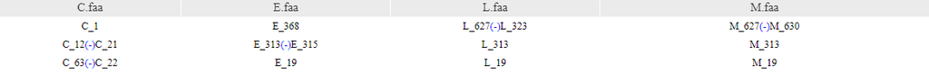

Comprobamos que las componentes extraídas son consistentes con la salida de proteinortho, usando como ejemplo 3 de sus filas(imagen arriba). La primera fila es consistente con la componente 11, la segunda fila es consistente con la componente 10 y la tercela fila con la componente 9.

A continuación, podemos visualizar todas las componentes de manera individual.

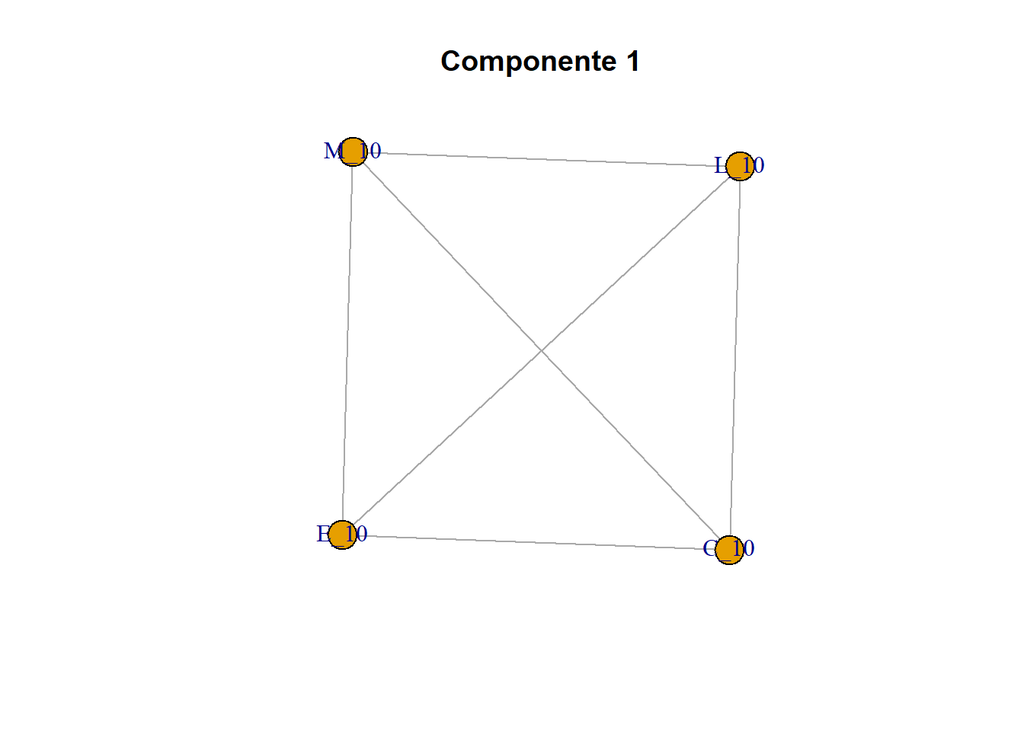

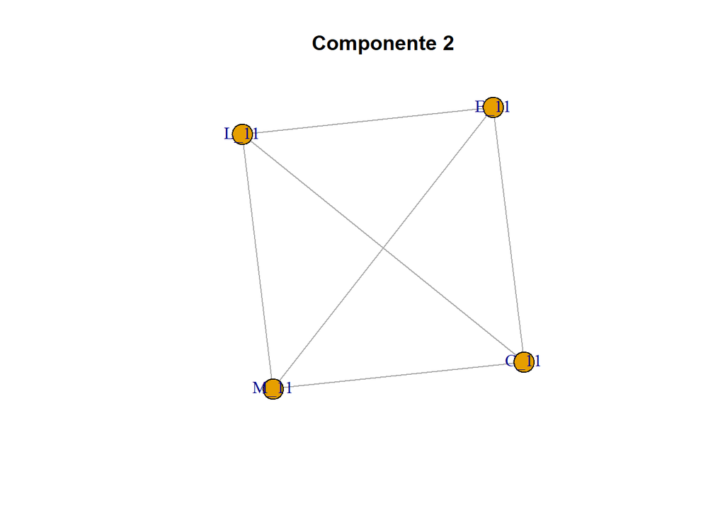

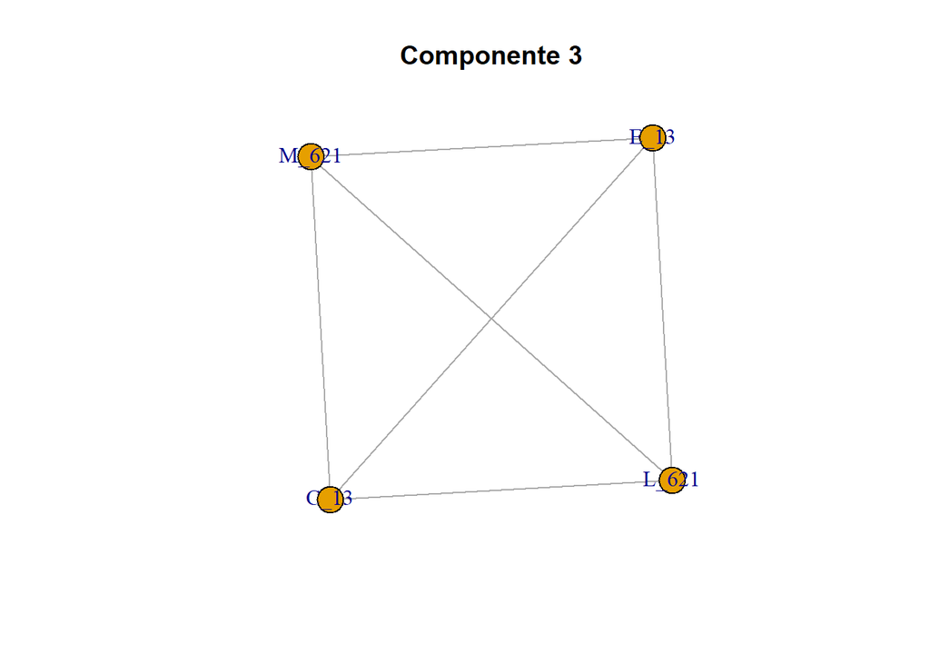

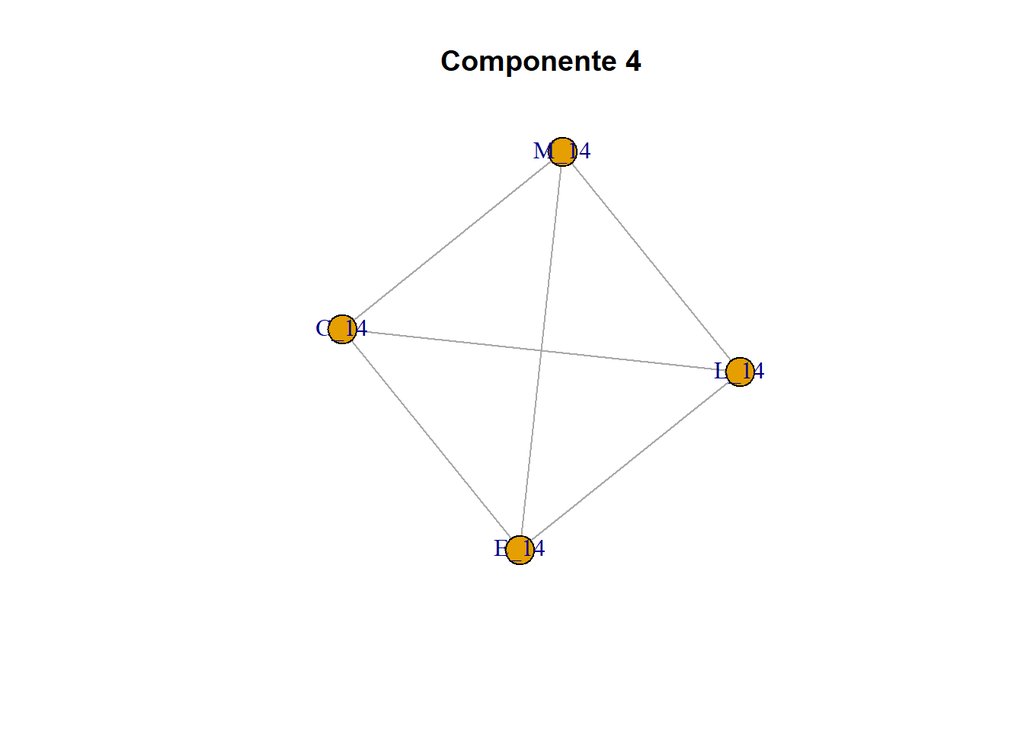

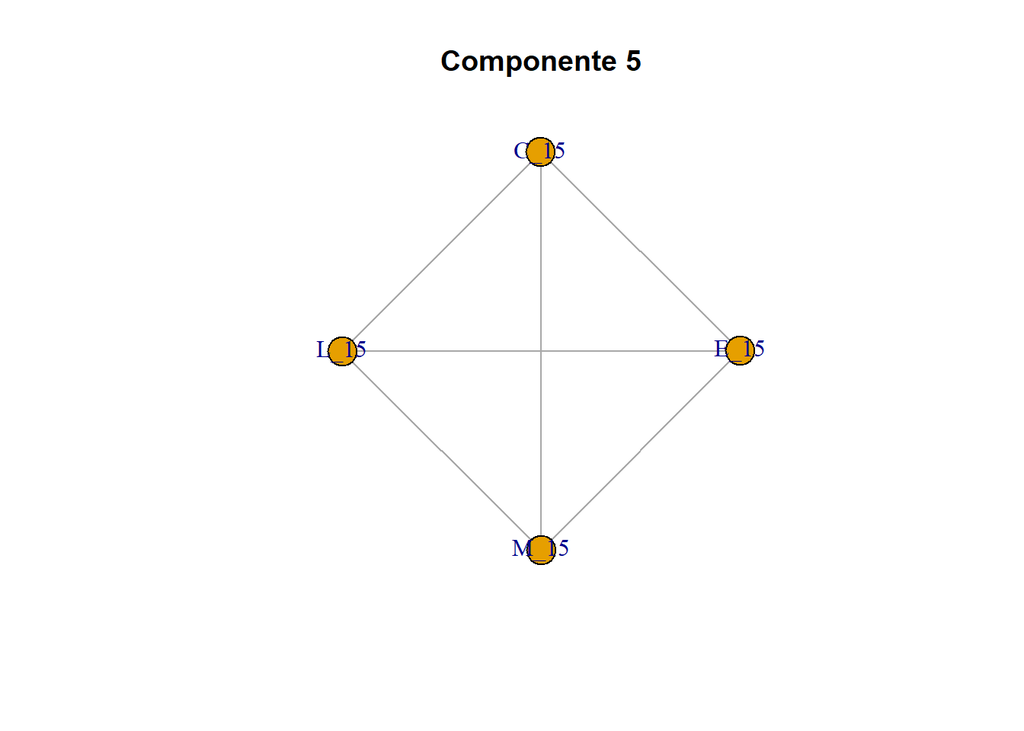

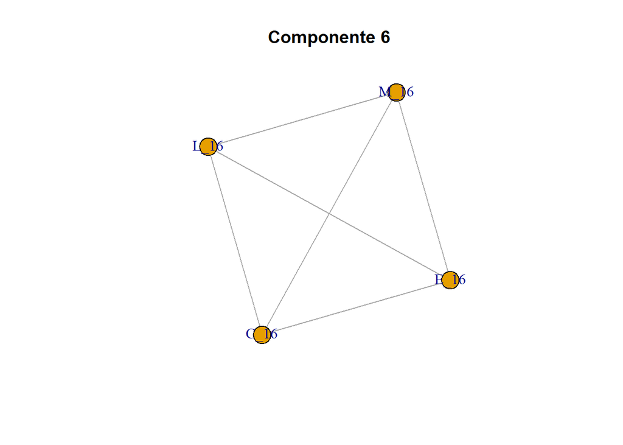

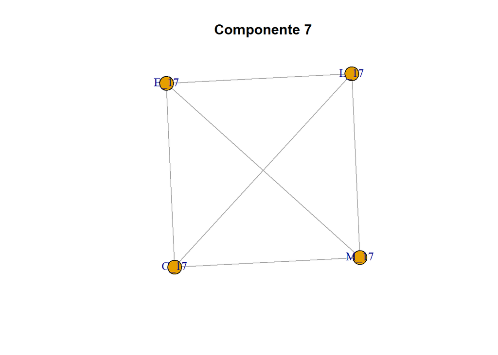

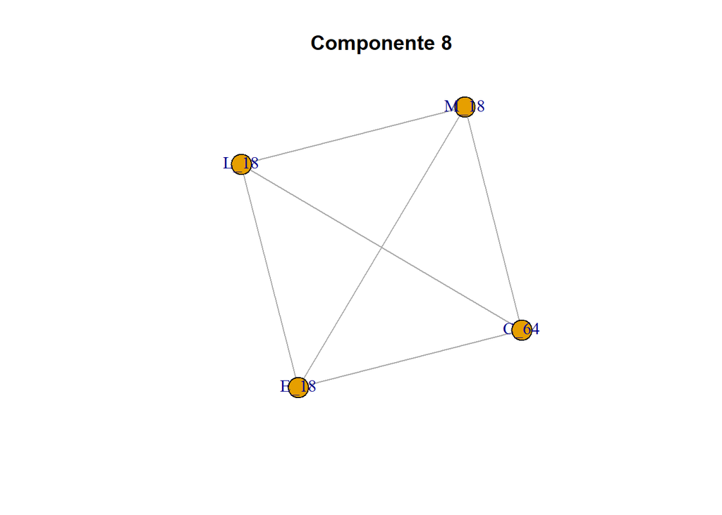

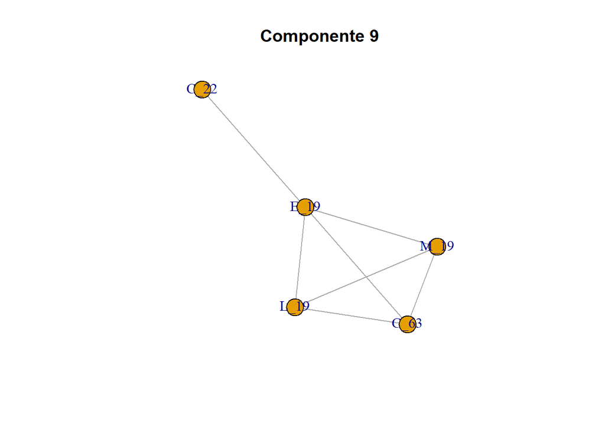

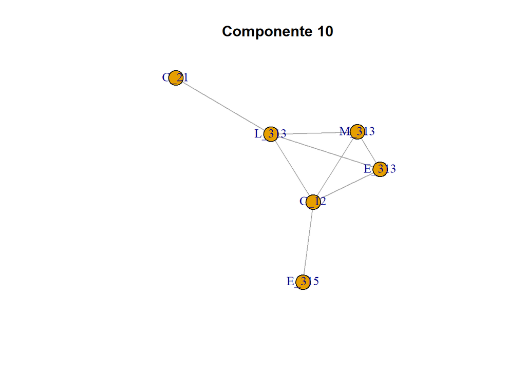

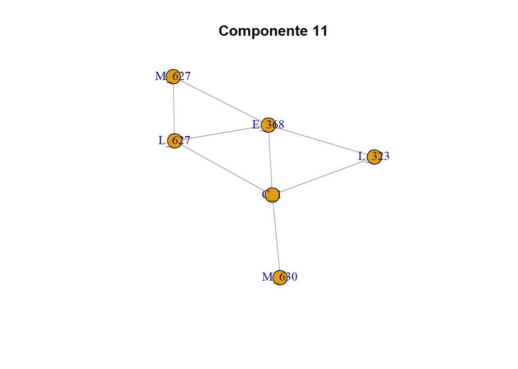

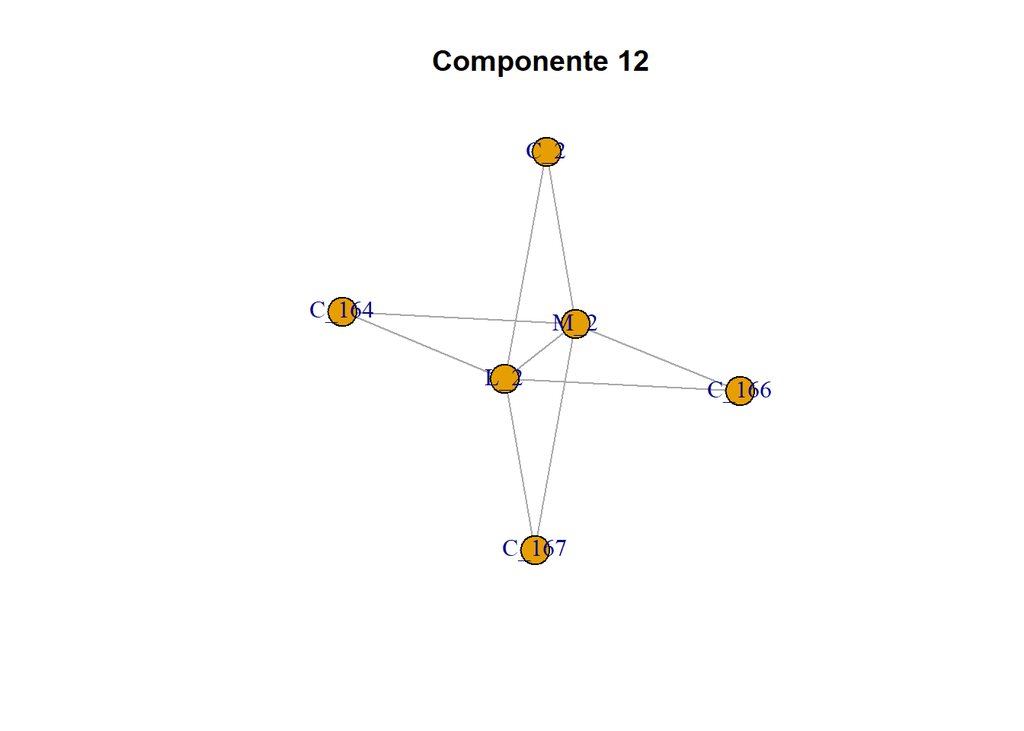

[22 more figures not shown]

```r
for (i in 1:length(gg)) {
  plot(gg[[i]], main = paste("Componente", i))
}
```

En este caso, podemos asumir visualizar cada una de los componentes y definir por ejemplo si son o no grafos completos.Pero si se tratase de una red de mayor “complejidad” sería mejor automatizar dicha tarea.

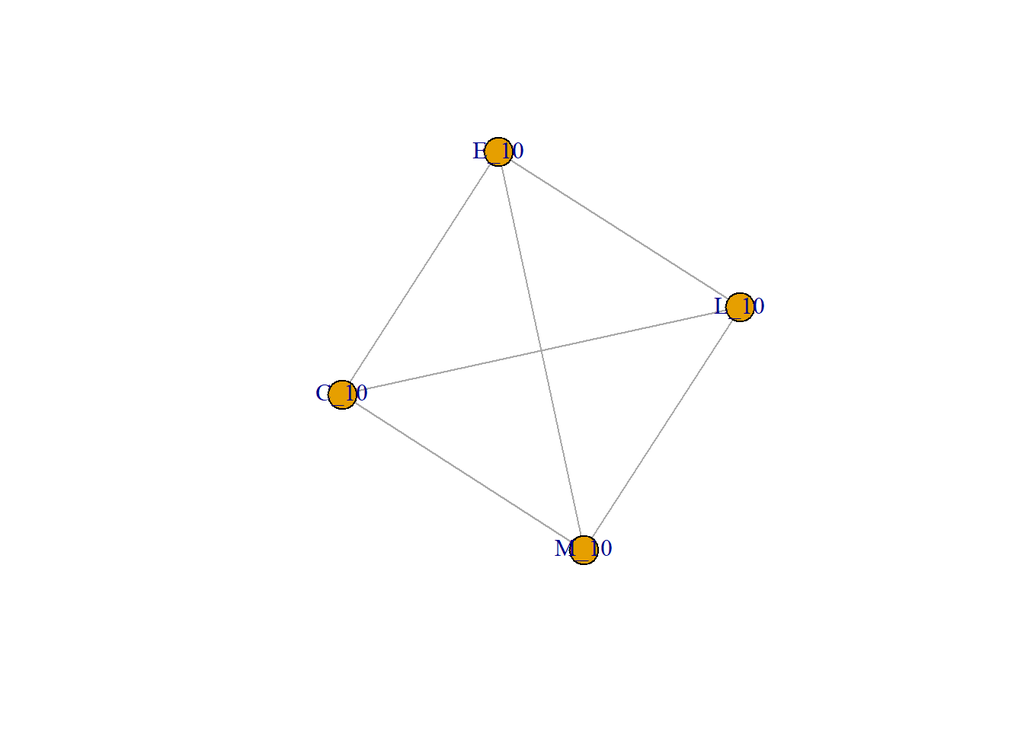

```r
#Crea una función para determinar si un componente es un grafo completo
is_complete_graph <- function(z) {
    n <- vcount(z)
    m <- ecount(z)
    m == (n * (n - 1)) / 2
}
complete_graphs <- lapply(gg, is_complete_graph) #Aplica la función is_complete_graph() a cada componente en tu lista de componentes
complete_graph_indices <- which(complete_graphs == TRUE) #crear una lista de índices de componentes que son grafos completos
complete_graph_components <- gg[complete_graph_indices] #Crea una lista de componentes que son grafos completos en tu red original
plot(complete_graph_components[[1]]) #Plot ejemplo del primer componente Kn
```

```r
#Componentes conexas
componentes <- list()
for (i in seq_along(gg)) {
  componente <- gg[[i]]
  # Extraemos los nombres de los vértices
  nombres_vertices <- V(componente)$name

  # Agregamos los nombres de los vértices a la variable componentes
  componentes[[i]] <- nombres_vertices
}

# Imprimimos la lista de componentes
print(componentes)
```

```
## [[1]]
## [1] "E_10" "M_10" "L_10" "C_10"
##
## [[2]]
## [1] "E_11" "M_11" "L_11" "C_11"
##
## [[3]]
## [1] "E_13"  "M_621" "L_621" "C_13"
##
## [[4]]
## [1] "E_14" "M_14" "L_14" "C_14"
##
## [[5]]
## [1] "E_15" "M_15" "L_15" "C_15"
##
## [[6]]
## [1] "E_16" "M_16" "L_16" "C_16"
##
## [[7]]
## [1] "E_17" "M_17" "L_17" "C_17"
##
## [[8]]
## [1] "E_18" "M_18" "L_18" "C_64"
##
## [[9]]
## [1] "E_19" "M_19" "L_19" "C_22" "C_63"
##
## [[10]]
## [1] "E_313" "E_315" "M_313" "L_313" "C_12"  "C_21"
##
## [[11]]
## [1] "E_368" "M_630" "L_323" "L_627" "M_627" "C_1"
##
## [[12]]
## [1] "M_2"   "L_2"   "C_164" "C_166" "C_167" "C_2"
##
## [[13]]
## [1] "M_20" "L_20" "C_20"
##
## [[14]]
```

[output cut: 46 more lines]

```
##
## [[30]]
## [1] "M_640" "M_642" "M_649" "L_641" "L_643"
##
## [[31]]
## [1] "M_644" "M_646" "L_645" "L_647"
##
## [[32]]
## [1] "M_8" "L_8"
##
## [[33]]
## [1] "M_9" "L_9"
##
## [[34]]
## [1] "M_323" "M_634" "E_317"
```

```r
# Accedemos a los elementos de la primera fila
(componentes[[1]][[1]])
```

```
## [1] "E_10"
```

```r
(componentes[[1]][[2]])
```

```
## [1] "M_10"
```

```r
(componentes[[1]][[3]])
```

```
## [1] "L_10"
```

```r
(componentes[[1]][[4]])
```

```
## [1] "C_10"
```

```r
#output *tsv proteinortho
# Leer archivo
ortogrupos <- read.table("ortogrupos.csv", header=FALSE, sep=" ", fill=TRUE)
ortogrupos
```

| V1 | V2 | V3 | V4 | V5 | V6 |
| --- | --- | --- | --- | --- | --- |
| C_1 | E_368 | L_627 | L_323 | M_627 | M_630 |
| C_12 | C_21 | E_313 | E_315 | L_313 | M_313 |
| C_63 | C_22 | E_19 | L_19 | M_19 |  |
| C_64 | E_18 | L_18 | M_18 |  |  |
| C_14 | E_14 | L_14 | M_14 |  |  |
| C_15 | E_15 | L_15 | M_15 |  |  |
| C_16 | E_16 | L_16 | M_16 |  |  |
| C_17 | E_17 | L_17 | M_17 |  |  |
| C_11 | E_11 | L_11 | M_11 |  |  |
| C_13 | E_13 | L_621 | M_621 |  |  |

[output cut: 24 more lines]

```r
# Crear una lista vacía para almacenar los elementos
lista_ortogrupos <- list()

# Recorrer cada fila del dataframe
for (i in 1:nrow(ortogrupos)) {

    # Crear un vector con los valores de la fila actual
    fila <- as.character(unlist(ortogrupos[i, ]))

    # Eliminar los valores vacíos de la fila
    fila <- fila[fila != ""]

    # Agregar el vector a la lista
    lista_ortogrupos[[i]] <- fila

}

# Imprimir la lista
print(lista_ortogrupos)
```

```
## [[1]]
## [1] "C_1"   "E_368" "L_627" "L_323" "M_627" "M_630"
##
## [[2]]
## [1] "C_12"  "C_21"  "E_313" "E_315" "L_313" "M_313"
##
## [[3]]
## [1] "C_63" "C_22" "E_19" "L_19" "M_19"
##
## [[4]]
## [1] "C_64" "E_18" "L_18" "M_18"
##
## [[5]]
## [1] "C_14" "E_14" "L_14" "M_14"
##
## [[6]]
## [1] "C_15" "E_15" "L_15" "M_15"
##
## [[7]]
## [1] "C_16" "E_16" "L_16" "M_16"
##
## [[8]]
## [1] "C_17" "E_17" "L_17" "M_17"
##
## [[9]]
## [1] "C_11" "E_11" "L_11" "M_11"
##
## [[10]]
## [1] "C_13"  "E_13"  "L_621" "M_621"
##
## [[11]]
## [1] "C_10" "E_10" "L_10" "M_10"
##
## [[12]]
## [1] "C_164" "C_166" "C_167" "C_2"   "L_2"   "M_2"
##
## [[13]]
## [1] "C_20" "L_20" "M_20"
##
## [[14]]
```

[output cut: 46 more lines]

```
##
## [[30]]
## [1] "L_619" "M_619"
##
## [[31]]
## [1] "L_623" "M_623"
##
## [[32]]
## [1] "L_635" "M_636"
##
## [[33]]
## [1] "L_8" "M_8"
##
## [[34]]
## [1] "L_9" "M_9"
```

```r
#Prueba para acceder a los elementos
lista_ortogrupos[[1]][[1]]
```

```
## [1] "C_1"
```

```r
lista_ortogrupos[[1]][[2]]
```

```
## [1] "E_368"
```

```r
lista_ortogrupos[[1]][[3]]
```

```
## [1] "L_627"
```

```r
lista_ortogrupos[[1]][[4]]
```

```
## [1] "L_323"
```

```r
# Inicializar una lista para almacenar los índices de las filas que coinciden
indices_coincidencia <- list()

# Loop for anidado para comparar cada elemento de las dos listas
for (i in 1:length(componentes)) {
  for (j in 1:length(lista_ortogrupos)) {
    # Comparar si coinciden todas las posiciones de la fila
    if (all(componentes[[i]] %in% lista_ortogrupos[[j]]) & all(lista_ortogrupos[[j]] %in% componentes[[i]])) {
      indices_coincidencia[[length(indices_coincidencia)+1]] <- c(i, j)  # Guardar el índice de la fila que coincide
    }
  }
}

# Mostrar los resultados
if (length(indices_coincidencia) == 0) {
  cat("No se encontraron coincidencias")
} else {
  cat("Se encontraron", length(indices_coincidencia), "coincidencias en las filas:")
  for (k in 1:length(indices_coincidencia)) {
    cat("\n- Fila", indices_coincidencia[[k]][1], "de componentes y fila", indices_coincidencia[[k]][2], "de lista_ortogrupos")
  }
}
```

```
## Se encontraron 34 coincidencias en las filas:
## - Fila 1 de componentes y fila 11 de lista_ortogrupos
## - Fila 2 de componentes y fila 9 de lista_ortogrupos
## - Fila 3 de componentes y fila 10 de lista_ortogrupos
## - Fila 4 de componentes y fila 5 de lista_ortogrupos
## - Fila 5 de componentes y fila 6 de lista_ortogrupos
## - Fila 6 de componentes y fila 7 de lista_ortogrupos
## - Fila 7 de componentes y fila 8 de lista_ortogrupos
## - Fila 8 de componentes y fila 4 de lista_ortogrupos
## - Fila 9 de componentes y fila 3 de lista_ortogrupos
## - Fila 10 de componentes y fila 2 de lista_ortogrupos
## - Fila 11 de componentes y fila 1 de lista_ortogrupos
## - Fila 12 de componentes y fila 12 de lista_ortogrupos
## - Fila 13 de componentes y fila 13 de lista_ortogrupos
## - Fila 14 de componentes y fila 23 de lista_ortogrupos
## - Fila 15 de componentes y fila 14 de lista_ortogrupos
## - Fila 16 de componentes y fila 17 de lista_ortogrupos
## - Fila 17 de componentes y fila 24 de lista_ortogrupos
## - Fila 18 de componentes y fila 25 de lista_ortogrupos
## - Fila 19 de componentes y fila 26 de lista_ortogrupos
## - Fila 20 de componentes y fila 15 de lista_ortogrupos
## - Fila 21 de componentes y fila 27 de lista_ortogrupos
## - Fila 22 de componentes y fila 28 de lista_ortogrupos
## - Fila 23 de componentes y fila 29 de lista_ortogrupos
## - Fila 24 de componentes y fila 16 de lista_ortogrupos
## - Fila 25 de componentes y fila 30 de lista_ortogrupos
## - Fila 26 de componentes y fila 31 de lista_ortogrupos
## - Fila 27 de componentes y fila 21 de lista_ortogrupos
## - Fila 28 de componentes y fila 32 de lista_ortogrupos
## - Fila 29 de componentes y fila 20 de lista_ortogrupos
## - Fila 30 de componentes y fila 18 de lista_ortogrupos
## - Fila 31 de componentes y fila 19 de lista_ortogrupos
## - Fila 32 de componentes y fila 33 de lista_ortogrupos
## - Fila 33 de componentes y fila 34 de lista_ortogrupos
## - Fila 34 de componentes y fila 22 de lista_ortogrupos
```